# Task02

Andronik Ordian

## Teen Gambling

```r
library(lattice)
library(latticeExtra)
library(MASS)

Gambling <- read.table("teengambling.txt")
Gambling$sex <- factor(Gambling$sex, labels = c("male", "female"))
summary(Gambling)
```

```
##      sex         status          income           verbal
##  male  :28   Min.   :18.00   Min.   : 0.600   Min.   : 1.00
##  female:19   1st Qu.:28.00   1st Qu.: 2.000   1st Qu.: 6.00
##              Median :43.00   Median : 3.250   Median : 7.00
##              Mean   :45.23   Mean   : 4.642   Mean   : 6.66
##              3rd Qu.:61.50   3rd Qu.: 6.210   3rd Qu.: 8.00
##              Max.   :75.00   Max.   :15.000   Max.   :10.00
##      gamble
##  Min.   :  0.0
##  1st Qu.:  1.1
##  Median :  6.0
##  Mean   : 19.3
##  3rd Qu.: 19.4
##  Max.   :156.0
```

Найдём незначимые признаки

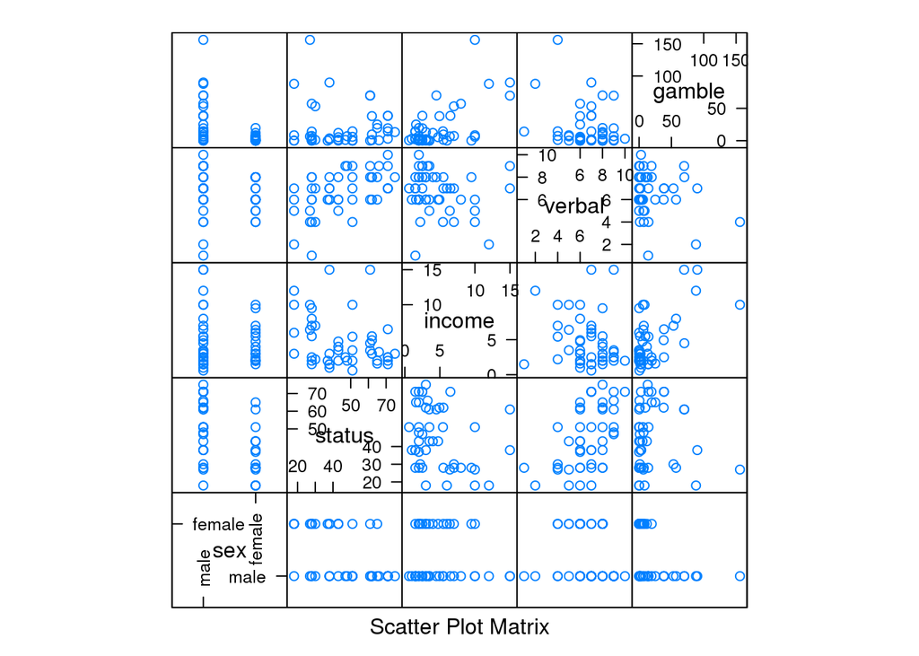

```r
splom(~Gambling)
```

```r
l <- lm(gamble ~ ., data = Gambling)
summary(l)
```

```
##
## Call:
## lm(formula = gamble ~ ., data = Gambling)
##
## Residuals:
##     Min      1Q  Median      3Q     Max
## -51.082 -11.320  -1.451   9.452  94.252
##
## Coefficients:
##              Estimate Std. Error t value Pr(>|t|)
## (Intercept)  22.55565   17.19680   1.312   0.1968
## sexfemale   -22.11833    8.21111  -2.694   0.0101 *
## status        0.05223    0.28111   0.186   0.8535
## income        4.96198    1.02539   4.839 1.79e-05 ***
## verbal       -2.95949    2.17215  -1.362   0.1803
## ---
## Signif. codes:  0 '***' 0.001 '**' 0.01 '*' 0.05 '.' 0.1 ' ' 1
##
## Residual standard error: 22.69 on 42 degrees of freedom
## Multiple R-squared:  0.5267, Adjusted R-squared:  0.4816
## F-statistic: 11.69 on 4 and 42 DF,  p-value: 1.815e-06
```

Кажется, что нужно удалить status и verbal, но давайте проверим на взаимное влияние признаков

```r
l2 <- lm(gamble ~ .^ 2, data = Gambling)
summary(l2)
```

```
##
## Call:
## lm(formula = gamble ~ .^2, data = Gambling)
##
## Residuals:
##     Min      1Q  Median      3Q     Max
## -43.591  -5.684  -2.105   4.951  76.197
##
## Coefficients:
##                  Estimate Std. Error t value Pr(>|t|)
## (Intercept)      -3.53592   43.30805  -0.082 0.935381
## sexfemale         3.83345   37.06202   0.103 0.918193
## status            0.62943    0.99135   0.635 0.529495
## income           12.30122    3.23858   3.798 0.000541 ***
## verbal           -5.95757    6.22209  -0.957 0.344708
## sexfemale:status  0.01565    0.53524   0.029 0.976840
## sexfemale:income -9.28795    2.86142  -3.246 0.002533 **
## sexfemale:verbal  1.96214    4.49463   0.437 0.665044
## status:income    -0.21089    0.09771  -2.158 0.037651 *
## status:verbal     0.03583    0.11442   0.313 0.755999
## income:verbal     0.50583    0.63884   0.792 0.433666
## ---
## Signif. codes:  0 '***' 0.001 '**' 0.01 '*' 0.05 '.' 0.1 ' ' 1
##
## Residual standard error: 19.86 on 36 degrees of freedom
## Multiple R-squared:  0.6892, Adjusted R-squared:  0.6029
## F-statistic: 7.983 on 10 and 36 DF,  p-value: 1.331e-06
```

```r
stepAIC(l2)
```

```
## Start:  AIC=290.41
## gamble ~ (sex + status + income + verbal)^2
##
##                 Df Sum of Sq   RSS    AIC
## - sex:status     1       0.3 14200 288.41
## - status:verbal  1      38.7 14239 288.54
## - sex:verbal     1      75.2 14275 288.66
## - income:verbal  1     247.3 14447 289.22
## <none>                       14200 290.41
## - status:income  1    1837.4 16037 294.13
## - sex:income     1    4155.9 18356 300.48
##
## Step:  AIC=288.41
## gamble ~ sex + status + income + verbal + sex:income + sex:verbal +
##     status:income + status:verbal + income:verbal
##
##                 Df Sum of Sq   RSS    AIC
## - status:verbal  1      38.5 14239 286.54
## - sex:verbal     1      87.8 14288 286.70
## - income:verbal  1     249.5 14450 287.23
## <none>                       14200 288.41
## - status:income  1    1919.6 16120 292.37
## - sex:income     1    5189.4 19390 301.05
##
## Step:  AIC=286.54
## gamble ~ sex + status + income + verbal + sex:income + sex:verbal +
##     status:income + income:verbal
##
##                 Df Sum of Sq   RSS    AIC
## - sex:verbal     1      65.7 14304 284.75
## - income:verbal  1     228.5 14467 285.29
## <none>                       14239 286.54
## - status:income  1    2003.1 16242 290.72
## - sex:income     1    5315.7 19554 299.45
##
## Step:  AIC=284.75
## gamble ~ sex + status + income + verbal + sex:income + status:income +
##     income:verbal
##
##                 Df Sum of Sq   RSS    AIC
## - income:verbal  1     264.5 14569 283.62
## <none>                       14304 284.75
## - status:income  1    2244.7 16549 289.61
## - sex:income     1    6220.9 20525 299.73
##
## Step:  AIC=283.62
## gamble ~ sex + status + income + verbal + sex:income + status:income
##
##                 Df Sum of Sq   RSS    AIC
## - verbal         1     381.9 14951 282.83
## <none>                       14569 283.62
## - status:income  1    3155.9 17725 290.83
## - sex:income     1    6294.0 20863 298.49
##
## Step:  AIC=282.83
## gamble ~ sex + status + income + sex:income + status:income
##
##                 Df Sum of Sq   RSS    AIC
## <none>                       14951 282.83
## - status:income  1    3514.0 18465 290.75
## - sex:income     1    6696.5 21647 298.23
```

```
##
## Call:
## lm(formula = gamble ~ sex + status + income + sex:income + status:income,
##     data = Gambling)
##
## Coefficients:
##      (Intercept)         sexfemale            status            income
##         -29.8693           15.1803            0.5899           13.8884
## sexfemale:income     status:income
##          -9.1007           -0.1698
```

Зависимость всё-таки есть, status удалять пока рано.

Давайте попробуем разбить выборку по полу и посмотреть на каждую в отдельности.

```r
library("latticist")
```

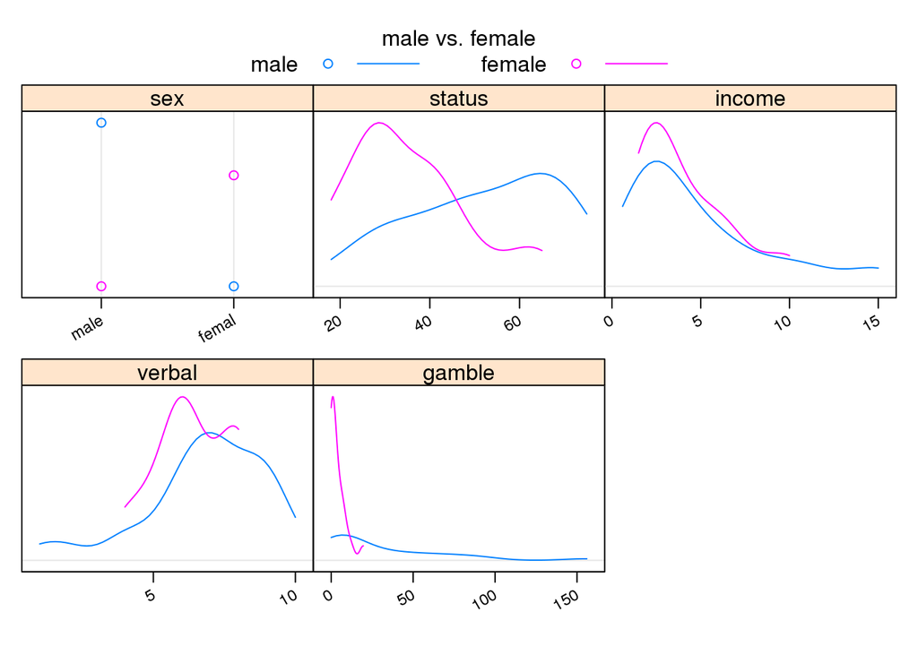

```r
marginal.plot(Gambling, data = Gambling, groups = sex,
auto.key = list(lines = TRUE, title = "male vs. female",
cex.title = 1, columns = 2))
```

Кажется девочек нужно совсем отбросить.

```r
Gambling.male <- subset(Gambling, sex == "male")
Gambling.male$sex <- NULL
l2.male <- lm(gamble ~ . ^ 2, data = Gambling.male)
l2.male.aic <- (stepAIC(l2.male))
```

```
## Start:  AIC=187.22
## gamble ~ (status + income + verbal)^2
##
##                 Df Sum of Sq   RSS    AIC
## - status:verbal  1     17.07 13628 185.26
## - income:verbal  1    455.13 14067 186.14
## <none>                       13611 187.22
## - status:income  1   2187.22 15799 189.39
##
## Step:  AIC=185.26
## gamble ~ status + income + verbal + status:income + income:verbal
##
##                 Df Sum of Sq   RSS    AIC
## - income:verbal  1    440.91 14069 184.15
## <none>                       13628 185.26
## - status:income  1   2239.21 15868 187.51
##
## Step:  AIC=184.15
## gamble ~ status + income + verbal + status:income
##
##                 Df Sum of Sq   RSS    AIC
## - verbal         1    400.38 14470 182.93
## <none>                       14069 184.15
## - status:income  1   2723.00 16792 187.10
##
## Step:  AIC=182.93
## gamble ~ status + income + status:income
##
##                 Df Sum of Sq   RSS    AIC
## <none>                       14470 182.93
## - status:income  1      2984 17454 186.18
```

```r
summary(l2.male.aic)
```

```
##
## Call:
## lm(formula = gamble ~ status + income + status:income, data = Gambling.male)
##
## Residuals:
##     Min      1Q  Median      3Q     Max
## -46.196 -14.394  -3.284  11.895  75.965
##
## Coefficients:
##                Estimate Std. Error t value Pr(>|t|)
## (Intercept)   -26.64338   28.83896  -0.924  0.36475
## status          0.53488    0.51827   1.032  0.31234
## income         13.79970    3.72913   3.701  0.00112 **
## status:income  -0.16948    0.07618  -2.225  0.03576 *
## ---
## Signif. codes:  0 '***' 0.001 '**' 0.01 '*' 0.05 '.' 0.1 ' ' 1
##
## Residual standard error: 24.55 on 24 degrees of freedom
## Multiple R-squared:  0.6153, Adjusted R-squared:  0.5672
## F-statistic:  12.8 on 3 and 24 DF,  p-value: 3.399e-05
```

Сравним простую модель с более сложной

```r
l.male <- lm(gamble ~ income, data = Gambling.male)
AIC(l.male, l2.male.aic)
```

```
##             df      AIC
## l.male       3 267.2070
## l2.male.aic  5 264.3937
```

```r
BIC(l.male, l2.male.aic)
```

```
##             df      BIC
## l.male       3 271.2036
## l2.male.aic  5 271.0548
```

```r
anova(l.male, l2.male.aic)
```

```
## Analysis of Variance Table
##
## Model 1: gamble ~ income
## Model 2: gamble ~ status + income + status:income
##   Res.Df   RSS Df Sum of Sq      F  Pr(>F)
## 1     26 18456
## 2     24 14470  2    3986.3 3.3059 0.05393 .
## ---
## Signif. codes:  0 '***' 0.001 '**' 0.01 '*' 0.05 '.' 0.1 ' ' 1
```

Простая модель не проигрывает. Видно, что у мальчиков играют роль лишь деньги.

Теперь девочки.

```r
Gambling.female <- subset(Gambling, sex == "female")
Gambling.female$sex <- NULL
Gambling.female$gamble
```

```
##  [1]  0.00  0.00  0.00  7.30 19.60  0.10  1.45  6.60  1.70  0.10  0.10
## [12]  5.40  1.20  3.60  2.40  3.40  0.10  8.40 12.00
```

Похоже у нас есть outlier.

```r
outlier <- function(x) x[x %in% boxplot.stats(x)$out]
outlier(Gambling.female$gamble)
```

```
## [1] 19.6
```

```r
Gambling.female <- Gambling.female[-5,]

l2.female <- lm(gamble ~ . ^ 2, data = Gambling.female)
summary(stepAIC(l2.female))
```

```
## Start:  AIC=43.28
## gamble ~ (status + income + verbal)^2
##
##                 Df Sum of Sq     RSS    AIC
## <none>                        91.574 43.282
## - income:verbal  1    19.494 111.067 44.756
## - status:verbal  1    28.956 120.530 46.227
## - status:income  1    30.559 122.132 46.465
```

```
##
## Call:
## lm(formula = gamble ~ (status + income + verbal)^2, data = Gambling.female)
##
## Residuals:
##     Min      1Q  Median      3Q     Max
## -4.6142 -1.4106  0.0612  1.0007  5.9258
##
## Coefficients:
##               Estimate Std. Error t value Pr(>|t|)
## (Intercept)   30.50979   21.73806   1.404   0.1881
## status        -1.21390    0.57795  -2.100   0.0596 .
## income         0.49613    1.63040   0.304   0.7666
## verbal        -3.55597    3.23775  -1.098   0.2955
## status:income  0.08494    0.04433   1.916   0.0817 .
## status:verbal  0.14829    0.07951   1.865   0.0891 .
## income:verbal -0.35616    0.23275  -1.530   0.1542
## ---
## Signif. codes:  0 '***' 0.001 '**' 0.01 '*' 0.05 '.' 0.1 ' ' 1
##
## Residual standard error: 2.885 on 11 degrees of freedom
## Multiple R-squared:  0.5765, Adjusted R-squared:  0.3455
## F-statistic: 2.495 on 6 and 11 DF,  p-value: 0.08966
```

Девочки почти не играют в азартные игры, поэтому сложно интерпретировать зависимость.

# Universities

```r
Universities <- read.csv2(file = "I.csv")
Universities <- subset(Universities, select = c(PPIND, AVRCOMB, NEW10, FULLTIME, IN_STATE, ROOM, ADD_FEE, PH_D, GRADUAT, SAL_FULL, NUM_FULL))
Universities$PPIND <- factor(Universities$PPIND, labels = c("Public", "Private"))

public <- subset(Universities, PPIND == "Public")
public$PPIND <- NULL
private <- subset(Universities, PPIND == "Private")
private$PPIND <- NULL
Universities <- na.exclude(Universities)
public <- na.exclude(public)
private <- na.exclude(private)
```

Найдём и удалим outliers.

```r
private
```

```
##     AVRCOMB NEW10 FULLTIME IN_STATE ROOM ADD_FEE PH_D GRADUAT SAL_FULL
## 19     1090    45    13259    17230 3566     330   90      68      802
## 23     1010    29     2666    15192 4695     330   84      67      623
## 25     1035    22    14130     3690 2280     410   82      75      723
## 35     1220    76     5544    17600 3600     230   97      96      796
## 53     1220    79     7671    16850 4400     147   96      97      798
## 71     1381    96     4481    20100 3200     600   99      94      903
## 72      998    16    11160    13380 3990     186   73      46      688
## 91     1319    87     3918    19545 3255     105   95      98      785
## 93     1355    90     4540    19900 2696     400   91      99      963
## 96     1130    35     2332    15960 2622     323   95      77      703
## 97     1300    78     3376    18624 3740     486   97      99      882
## 99     1041    30     4740    14235 6965     170   86      80      744
## 100    1010    25     6534    11600 3620     650   81      60      757
## 108    1302    90     6188    18590 2996     480   95      97      854
```

[output cut: 21 more lines]

```r
outlier(private$ADD_FEE)
```

```
## [1] 1836
```

```r
outlier(private$IN_STATE)
```

```
## [1] 3690
```

```r
private <- private[-c(3, 15),]
Universities <- Universities[-c(25, 129),]
```

University of Delawa и University of Pennsy портили нам всю картину.

Воспользуемся результатами практики

```r
fit1 <- lm(NEW10 ~ AVRCOMB + FULLTIME + log(IN_STATE) +
log(ROOM) + log(ADD_FEE) + log(SAL_FULL) +
PH_D + GRADUAT + NUM_FULL, data = private)
summary(fit1)
```

```
##
## Call:
## lm(formula = NEW10 ~ AVRCOMB + FULLTIME + log(IN_STATE) + log(ROOM) +
##     log(ADD_FEE) + log(SAL_FULL) + PH_D + GRADUAT + NUM_FULL,
##     data = private)
##
## Residuals:
##      19      23      35      53      71      72      91      93      96
## -0.2324  5.6579  4.0357  3.2502  3.1590 -2.7679  2.4181 -1.6382 -5.0773
##      97      99     100     108     131     137
## -4.2636 -5.3693  2.6164  1.0907 -6.5424  3.6630
##
## Coefficients:
##                 Estimate Std. Error t value Pr(>|t|)
## (Intercept)   -7.902e+01  6.208e+02  -0.127   0.9037
## AVRCOMB        1.791e-01  6.470e-02   2.768   0.0394 *
## FULLTIME       2.162e-03  9.183e-04   2.354   0.0652 .
## log(IN_STATE)  2.426e+00  3.596e+01   0.067   0.9488
## log(ROOM)      7.109e+00  1.462e+01   0.486   0.6473
## log(ADD_FEE)   5.594e+00  3.759e+00   1.488   0.1969
## log(SAL_FULL) -3.365e+01  4.866e+01  -0.692   0.5200
## PH_D          -4.079e-01  7.340e-01  -0.556   0.6024
## GRADUAT        7.761e-01  6.127e-01   1.267   0.2611
## NUM_FULL      -1.027e-02  3.209e-02  -0.320   0.7619
## ---
## Signif. codes:  0 '***' 0.001 '**' 0.01 '*' 0.05 '.' 0.1 ' ' 1
##
## Residual standard error: 6.665 on 5 degrees of freedom
## Multiple R-squared:  0.9805, Adjusted R-squared:  0.9455
## F-statistic: 27.98 on 9 and 5 DF,  p-value: 0.0009377
```

```r
fit2 <- lm(NEW10 ~ FULLTIME + log(IN_STATE) +
log(ROOM) + log(ADD_FEE) + log(SAL_FULL) +
PH_D + GRADUAT + NUM_FULL, data = private)
summary(fit2)
```

```
##
## Call:
## lm(formula = NEW10 ~ FULLTIME + log(IN_STATE) + log(ROOM) + log(ADD_FEE) +
##     log(SAL_FULL) + PH_D + GRADUAT + NUM_FULL, data = private)
##
## Residuals:
##     Min      1Q  Median      3Q     Max
## -8.1242 -6.7759 -0.5805  4.6927 11.3227
##
## Coefficients:
##                 Estimate Std. Error t value Pr(>|t|)
## (Intercept)   -1.540e+02  9.011e+02  -0.171   0.8699
## FULLTIME       1.729e-03  1.315e-03   1.315   0.2366
## log(IN_STATE)  4.176e+01  4.800e+01   0.870   0.4177
## log(ROOM)     -1.700e+01  1.706e+01  -0.996   0.3575
## log(ADD_FEE)   6.308e+00  5.449e+00   1.158   0.2910
## log(SAL_FULL) -2.292e+01  7.047e+01  -0.325   0.7560
## PH_D          -1.037e+00  1.014e+00  -1.023   0.3457
## GRADUAT        1.736e+00  7.338e-01   2.366   0.0558 .
## NUM_FULL       1.626e-02  4.449e-02   0.366   0.7273
## ---
## Signif. codes:  0 '***' 0.001 '**' 0.01 '*' 0.05 '.' 0.1 ' ' 1
##
## Residual standard error: 9.684 on 6 degrees of freedom
## Multiple R-squared:  0.9507, Adjusted R-squared:  0.885
## F-statistic: 14.46 on 8 and 6 DF,  p-value: 0.002142
```

```r
fit2.manual1 <- lm(NEW10 ~ FULLTIME + log(IN_STATE) + GRADUAT, data = private)
summary(fit2.manual1)
```

```
##
## Call:
## lm(formula = NEW10 ~ FULLTIME + log(IN_STATE) + GRADUAT, data = private)
##
## Residuals:
##      Min       1Q   Median       3Q      Max
## -14.8015  -3.5242   0.3951   5.2176  13.9911
##
## Coefficients:
##                 Estimate Std. Error t value Pr(>|t|)
## (Intercept)   -6.992e+02  2.581e+02  -2.709  0.02034 *
## FULLTIME       1.424e-03  9.813e-04   1.451  0.17458
## log(IN_STATE)  6.769e+01  2.878e+01   2.352  0.03835 *
## GRADUAT        1.125e+00  2.992e-01   3.759  0.00316 **
## ---
## Signif. codes:  0 '***' 0.001 '**' 0.01 '*' 0.05 '.' 0.1 ' ' 1
##
## Residual standard error: 9.283 on 11 degrees of freedom
## Multiple R-squared:  0.9169, Adjusted R-squared:  0.8943
## F-statistic: 40.47 on 3 and 11 DF,  p-value: 3.102e-06
```

```r
fit2.manual2 <- lm(NEW10 ~ GRADUAT, data = private)
summary(fit2.manual2)
```

```
##
## Call:
## lm(formula = NEW10 ~ GRADUAT, data = private)
##
## Residuals:
##     Min      1Q  Median      3Q     Max
## -26.309  -6.120   2.958   7.339  18.121
##
## Coefficients:
##             Estimate Std. Error t value Pr(>|t|)
## (Intercept)  -66.947     16.063  -4.168   0.0011 **
## GRADUAT        1.541      0.188   8.196 1.71e-06 ***
## ---
## Signif. codes:  0 '***' 0.001 '**' 0.01 '*' 0.05 '.' 0.1 ' ' 1
##
## Residual standard error: 11.93 on 13 degrees of freedom
## Multiple R-squared:  0.8379, Adjusted R-squared:  0.8254
## F-statistic: 67.18 on 1 and 13 DF,  p-value: 1.713e-06
```

```r
fit2.aic <- stepAIC(fit2)
```

```
## Start:  AIC=72.37
## NEW10 ~ FULLTIME + log(IN_STATE) + log(ROOM) + log(ADD_FEE) +
##     log(SAL_FULL) + PH_D + GRADUAT + NUM_FULL
##
##                 Df Sum of Sq     RSS    AIC
## - log(SAL_FULL)  1      9.92  572.56 70.631
## - NUM_FULL       1     12.53  575.16 70.699
## - log(IN_STATE)  1     71.00  633.63 72.151
## <none>                        562.63 72.369
## - log(ROOM)      1     93.11  655.74 72.666
## - PH_D           1     98.19  660.82 72.781
## - log(ADD_FEE)   1    125.68  688.31 73.393
## - FULLTIME       1    162.13  724.77 74.167
## - GRADUAT        1    524.98 1087.62 80.255
##
## Step:  AIC=70.63
## NEW10 ~ FULLTIME + log(IN_STATE) + log(ROOM) + log(ADD_FEE) +
##     PH_D + GRADUAT + NUM_FULL
##
##                 Df Sum of Sq     RSS    AIC
## - NUM_FULL       1      3.20  575.75 68.714
## <none>                        572.56 70.631
## - PH_D           1     93.57  666.12 70.901
## - log(ROOM)      1    100.21  672.76 71.050
## - log(ADD_FEE)   1    116.76  689.32 71.415
## - log(IN_STATE)  1    146.48  719.04 72.048
## - FULLTIME       1    152.21  724.77 72.167
## - GRADUAT        1   1245.08 1817.64 85.959
##
## Step:  AIC=68.71
## NEW10 ~ FULLTIME + log(IN_STATE) + log(ROOM) + log(ADD_FEE) +
##     PH_D + GRADUAT
##
##                 Df Sum of Sq     RSS    AIC
## <none>                        575.75 68.714
## - log(ROOM)      1     97.07  672.83 69.052
## - PH_D           1    105.44  681.19 69.237
## - log(ADD_FEE)   1    196.33  772.08 71.116
## - log(IN_STATE)  1    236.12  811.87 71.869
## - FULLTIME       1    265.27  841.02 72.399
## - GRADUAT        1   1288.75 1864.51 84.341
```

```r
summary(fit2.aic)
```

```
##
## Call:
## lm(formula = NEW10 ~ FULLTIME + log(IN_STATE) + log(ROOM) + log(ADD_FEE) +
##     PH_D + GRADUAT, data = private)
##
## Residuals:
##     Min      1Q  Median      3Q     Max
## -8.3049 -6.5829  0.3984  4.5794 12.2175
##
## Coefficients:
##                 Estimate Std. Error t value Pr(>|t|)
## (Intercept)   -4.554e+02  3.103e+02  -1.468  0.18041
## FULLTIME       1.756e-03  9.145e-04   1.920  0.09113 .
## log(IN_STATE)  5.420e+01  2.992e+01   1.811  0.10767
## log(ROOM)     -1.290e+01  1.111e+01  -1.161  0.27896
## log(ADD_FEE)   6.501e+00  3.936e+00   1.652  0.13721
## PH_D          -9.003e-01  7.438e-01  -1.210  0.26067
## GRADUAT        1.552e+00  3.668e-01   4.232  0.00287 **
## ---
## Signif. codes:  0 '***' 0.001 '**' 0.01 '*' 0.05 '.' 0.1 ' ' 1
##
## Residual standard error: 8.483 on 8 degrees of freedom
## Multiple R-squared:  0.9495, Adjusted R-squared:  0.9117
## F-statistic: 25.09 on 6 and 8 DF,  p-value: 8.953e-05
```

```r
library(e1071)
l <- update(fit2.aic, . ~ . - log(ADD_FEE))
tune(lm, fit2.aic$call$formula, data = private,
tunecontrol = tune.control(sampling = "cross",
cross = 15))
```

```
##
## Error estimation of 'lm' using leave-one-out: 251.9114
```

```r
tune(lm, l$call$formula, data = private, tunecontrol = tune.control(sampling = "cross",
cross = 15))
```

```
##
## Error estimation of 'lm' using leave-one-out: 273.3321
```

С ADD_FEE вывод тот же, он значим. Сравниваем модели

```r
AIC(fit1, fit2, fit2.aic, fit2.manual1, fit2.manual2, l)
```

```
##              df      AIC
## fit1         11 104.9964
## fit2         10 116.9368
## fit2.aic      8 113.2825
## fit2.manual1  5 114.7612
## fit2.manual2  3 120.7920
## l             7 115.6837
```

```r
BIC(fit1, fit2, fit2.aic, fit2.manual1, fit2.manual2, l)
```

```
##              df      BIC
## fit1         11 112.7849
## fit2         10 124.0173
## fit2.aic      8 118.9469
## fit2.manual1  5 118.3015
## fit2.manual2  3 122.9162
## l             7 120.6401
```

```r
anova(fit1, fit2, fit2.aic, fit2.manual1, fit2.manual2, l)
```

```
## Analysis of Variance Table
##
## Model 1: NEW10 ~ AVRCOMB + FULLTIME + log(IN_STATE) + log(ROOM) + log(ADD_FEE) +
##     log(SAL_FULL) + PH_D + GRADUAT + NUM_FULL
## Model 2: NEW10 ~ FULLTIME + log(IN_STATE) + log(ROOM) + log(ADD_FEE) +
##     log(SAL_FULL) + PH_D + GRADUAT + NUM_FULL
## Model 3: NEW10 ~ FULLTIME + log(IN_STATE) + log(ROOM) + log(ADD_FEE) +
##     PH_D + GRADUAT
## Model 4: NEW10 ~ FULLTIME + log(IN_STATE) + GRADUAT
## Model 5: NEW10 ~ GRADUAT
## Model 6: NEW10 ~ FULLTIME + log(IN_STATE) + log(ROOM) + PH_D + GRADUAT
##   Res.Df     RSS Df Sum of Sq       F  Pr(>F)
## 1      5  222.13
## 2      6  562.63 -1   -340.50  7.6645 0.03944 *
## 3      8  575.75 -2    -13.12  0.1476 0.86637
## 4     11  947.91 -3   -372.16  2.7923 0.14876
## 5     13 1850.06 -2   -902.15 10.1534 0.01735 *
## 6      9  772.08  4   1077.98  6.0661 0.03708 *
## ---
## Signif. codes:  0 '***' 0.001 '**' 0.01 '*' 0.05 '.' 0.1 ' ' 1
```

Удивительно, но aic проигрывает. Кажется, в этот раз наиболее значимым фактором является процент выпустившихся.

Корреляция признаков.

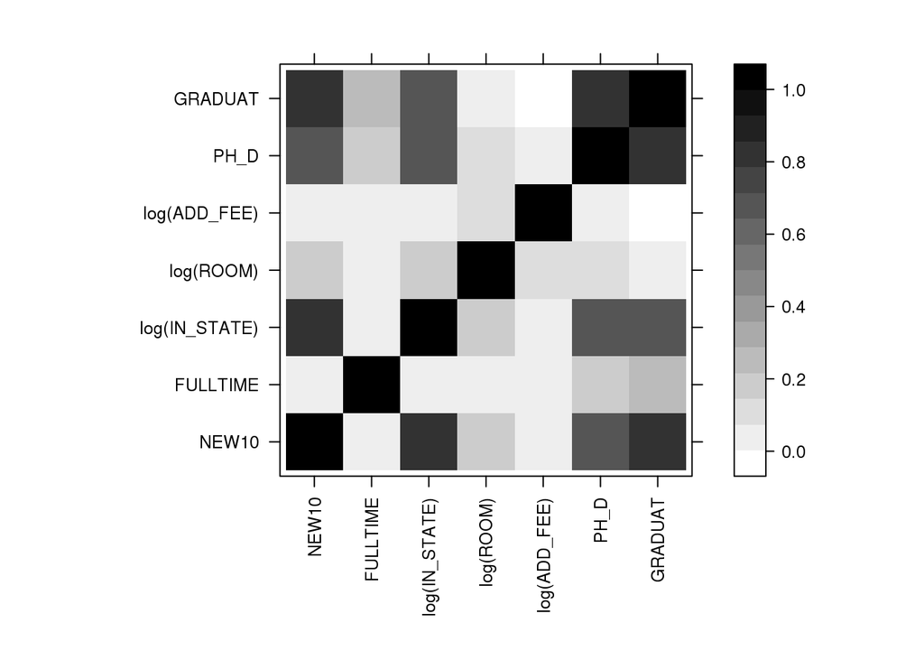

```r
levelplot(cor(fit2.aic$model)^2, par.settings = list(regions = list(col = colorRampPalette(grey(1:0)))),
scales = list(x = list(rot = 90)), xlab = "",
ylab = "")
```

Теперь построим модель для всех университетов, используя эффекты взаимодействия с фактором PPIND, используя признаки, отобранные при анализе видов университетов отдельно.

```r
contrasts(Universities$PPIND) <- contr.sum
overall <- lm(NEW10 ~ (GRADUAT + log(IN_STATE) + log(ADD_FEE)) * PPIND, data = Universities)
summary(overall)
```

```
##
## Call:
## lm(formula = NEW10 ~ (GRADUAT + log(IN_STATE) + log(ADD_FEE)) *
##     PPIND, data = Universities)
##
## Residuals:
##      Min       1Q   Median       3Q      Max
## -26.2271  -4.5240   0.1207   5.7495  19.5760
##
## Coefficients:
##                      Estimate Std. Error t value Pr(>|t|)
## (Intercept)          -84.2090    36.2001  -2.326   0.0243 *
## GRADUAT                1.0819     0.1092   9.909 3.41e-13 ***
## log(IN_STATE)          4.1720     3.8451   1.085   0.2833
## log(ADD_FEE)          -0.4336     2.1033  -0.206   0.8375
## PPIND1               197.2709    36.2001   5.449 1.72e-06 ***
## GRADUAT:PPIND1        -0.2632     0.1092  -2.411   0.0198 *
## log(IN_STATE):PPIND1 -17.3594     3.8451  -4.515 4.12e-05 ***
## log(ADD_FEE):PPIND1   -4.3969     2.1033  -2.090   0.0419 *
## ---
## Signif. codes:  0 '***' 0.001 '**' 0.01 '*' 0.05 '.' 0.1 ' ' 1
##
## Residual standard error: 10.08 on 48 degrees of freedom
## Multiple R-squared:  0.8521, Adjusted R-squared:  0.8306
## F-statistic: 39.52 on 7 and 48 DF,  p-value: < 2.2e-16
```

Выкинем лишнее

```r
overall.aic <- stepAIC(overall)
```

```
## Start:  AIC=266.09
## NEW10 ~ (GRADUAT + log(IN_STATE) + log(ADD_FEE)) * PPIND
##
##                       Df Sum of Sq    RSS    AIC
## <none>                             4872.3 266.10
## - log(ADD_FEE):PPIND   1    443.59 5315.9 268.97
## - GRADUAT:PPIND        1    589.91 5462.2 270.50
## - log(IN_STATE):PPIND  1   2068.94 6941.3 283.91
```

```r
summary(overall.aic)
```

```
##
## Call:
## lm(formula = NEW10 ~ (GRADUAT + log(IN_STATE) + log(ADD_FEE)) *
##     PPIND, data = Universities)
##
## Residuals:
##      Min       1Q   Median       3Q      Max
## -26.2271  -4.5240   0.1207   5.7495  19.5760
##
## Coefficients:
##                      Estimate Std. Error t value Pr(>|t|)
## (Intercept)          -84.2090    36.2001  -2.326   0.0243 *
## GRADUAT                1.0819     0.1092   9.909 3.41e-13 ***
## log(IN_STATE)          4.1720     3.8451   1.085   0.2833
## log(ADD_FEE)          -0.4336     2.1033  -0.206   0.8375
## PPIND1               197.2709    36.2001   5.449 1.72e-06 ***
## GRADUAT:PPIND1        -0.2632     0.1092  -2.411   0.0198 *
## log(IN_STATE):PPIND1 -17.3594     3.8451  -4.515 4.12e-05 ***
## log(ADD_FEE):PPIND1   -4.3969     2.1033  -2.090   0.0419 *
## ---
## Signif. codes:  0 '***' 0.001 '**' 0.01 '*' 0.05 '.' 0.1 ' ' 1
##
## Residual standard error: 10.08 on 48 degrees of freedom
## Multiple R-squared:  0.8521, Adjusted R-squared:  0.8306
## F-statistic: 39.52 on 7 and 48 DF,  p-value: < 2.2e-16
```

Попробуем протестировать

```r
train.idx <- sample(nrow(Universities), size = nrow(Universities) * 2/3)
Universities.train <- Universities[train.idx, ]
Universities.test <- Universities[-train.idx, ]

Universities.lm.train <- lm(overall.aic$call$formula, data = Universities.train)
```

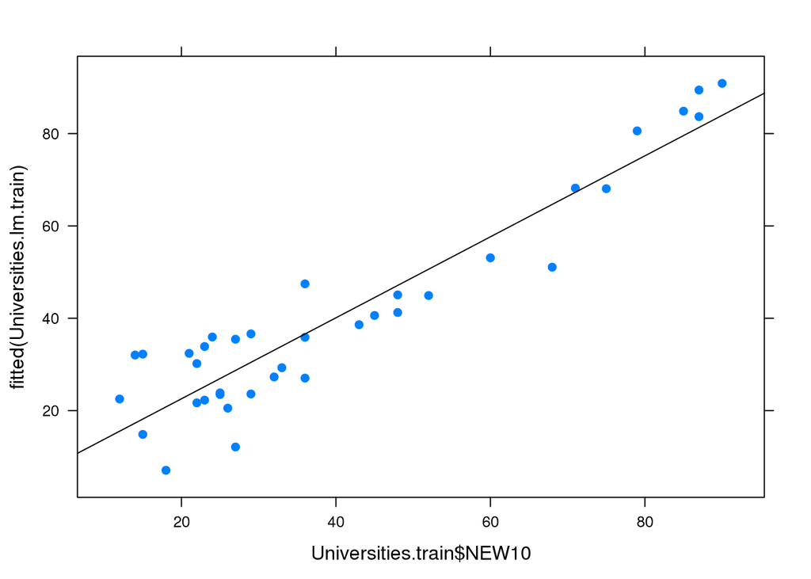

```r
panel <- function(...) {
  panel.xyplot(...)
  panel.lmline(...)
}
xyplot(fitted(Universities.lm.train) ~ Universities.train$NEW10, panel = panel, pch = 19)
```

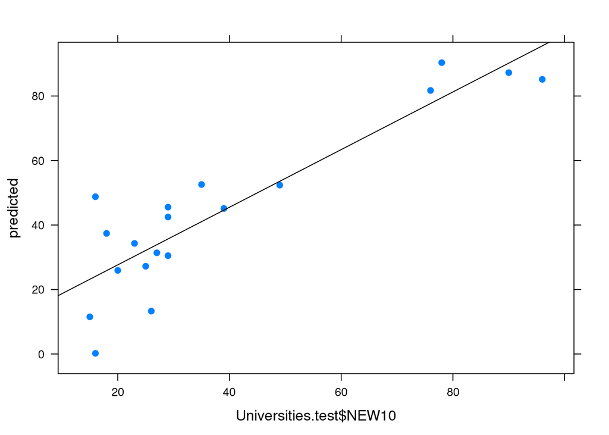

```r
predicted <- predict(Universities.lm.train, Universities.test)
xyplot(predicted ~ Universities.test$NEW10, panel = panel, pch = 19)
```

Результат не так уж и плох, но не впечатляет.